# For the data shared build a classification model using CNN and

## Keras and perform below tasks.

• Plot the test and validation, loss and accuracy.

• Check for overfitting and apply L1, L2 regularisation, early stopping and dropout techniques.

• Display confusion matrix

• Calculate accuracy, precision and recall

# Problem Statement:

- To build a deep learning classification model using Convolutional Neural Networks (CNN) in Keras that can accurately identify whether a patient is suffering from pneumonia or not by analyzing chest X-ray images.

## Objective:

1) The objective is to create an accurate and efficient model that can help improve the diagnosis of pneumonia, especially in regions where medical resources and personnel are limited.

##### There are two categories:-

- NORMAL
- PNEUMONIA

```python
! pip install opencv-python
```

```python
import numpy as np
import pandas as pd
import random
import matplotlib.pyplot as plt
%matplotlib inline
import os
import cv2

import keras.backend as K
from keras.models import Model, Sequential
from keras.layers import Input, Dense, Flatten, Dropout, BatchNormalization
from keras.layers import Conv2D, SeparableConv2D, MaxPool2D, LeakyReLU, Activation
from keras.optimizers import Adam
from keras.preprocessing.image import ImageDataGenerator
from keras.callbacks import ModelCheckpoint, ReduceLROnPlateau, EarlyStopping
import tensorflow as tf
```

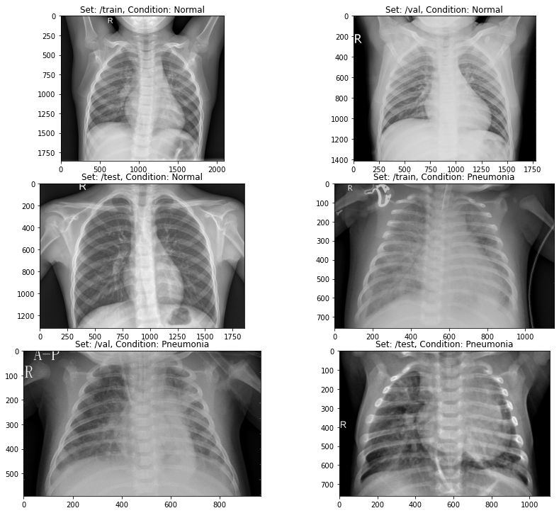

```python
data="C:\TGushpu  ANN & DL\chest_xray_images\chest_xray"
fig, ax = plt.subplots(3, 2, figsize=(12,10))
ax = ax.ravel()
plt.tight_layout()

for i, set in enumerate(['/train', '/val', '/test']):
    set_path = data+set
    ax[i].imshow(plt.imread(set_path+'/NORMAL/'+os.listdir(set_path+'/NORMAL')[0]), cmap='gray')
    ax[i].set_title('Set: {}, Condition: Normal'.format(set))
    ax[i+3].imshow(plt.imread(set_path+'/PNEUMONIA/'+os.listdir(set_path+'/PNEUMONIA')[0]), cmap='gray')
    ax[i+3].set_title('Set: {}, Condition: Pneumonia'.format(set))
```

```python
for set in ['/train', '/val', '/test']:
    n_normal = len(os.listdir(data + set + '/NORMAL'))
    n_infect = len(os.listdir(data + set + '/PNEUMONIA'))
    print('Set: {}, normal images: {}, pneumonia images: {}'.format(_set, n_normal, n_infect))
```

```
Set: /train, normal images: 1341, pneumonia images: 3875
Set: /train, normal images: 8, pneumonia images: 8
Set: /train, normal images: 234, pneumonia images: 390
```

## Rescale the image by normalzing:

- By using keras inbuild function to ImageDataGenerator so we donnot need to lable all images into 0 and 1 it automatic create it and batch also during train

```python
def process_data(img_dims, batch_size):
    train_datagen = ImageDataGenerator(rescale=1./255, zoom_range=0.3, vertical_flip=True)
    test_val_datagen = ImageDataGenerator(rescale=1./255)

    train_gen = train_datagen.flow_from_directory(
    directory=data+'/train',
    target_size=(img_dims, img_dims),
    batch_size=batch_size,
    class_mode='binary',
    shuffle=True)

    test_gen = test_val_datagen.flow_from_directory(
    directory=data+'/test',
    target_size=(img_dims, img_dims),
    batch_size=batch_size,
    class_mode='binary',
    shuffle=True)

    test_data = []
    test_labels = []

    for cond in ['/NORMAL/', '/PNEUMONIA/']:
        for img in (os.listdir(data + '/test' + cond)):
            img = plt.imread(data+'/test'+cond+img)
            img = cv2.resize(img, (img_dims, img_dims))
            img = np.dstack([img, img, img])
            img = img.astype('float32') / 255
            if cond=='/NORMAL/':
                label = 0
            elif cond=='/PNEUMONIA/':
                label = 1
            test_data.append(img)
            test_labels.append(label)

    test_data = np.array(test_data)
    test_labels = np.array(test_labels)

    return train_gen, test_gen, test_data, test_labels
```

- target_size: is the size of input images, every image will be resized to this size.
- color_mode: if the image is either black and white or grayscale set “grayscale” or if the image has three color channels, set “rgb”.
- batch_size: No. of images to be yielded from the generator per batch.
- class_mode: Set “binary” if you have only two classes to predict, if not set to“categorical”, in case if you’re developing an Autoencoder system, both input and the output would probably be the same image, for this case set to “input”.

```python
img_dims = 150
epochs = 10
batch_size = 32

train_gen, test_gen, test_data, test_labels = process_data(img_dims, batch_size)
```

```
Found 5216 images belonging to 2 classes.
Found 624 images belonging to 2 classes.
```

```python
inputs = Input(shape=(img_dims, img_dims, 3))

# 1st conv block
x = Conv2D(filters=16, kernel_size=(3, 3), activation='relu', padding='same')(inputs)
x = Conv2D(filters=16, kernel_size=(3, 3), activation='relu', padding='same')(x)
x = MaxPool2D(pool_size=(2, 2))(x)

# 2nd conv block
x = SeparableConv2D(filters=32, kernel_size=(3, 3), activation='relu', padding='same')(x)
x = SeparableConv2D(filters=32, kernel_size=(3, 3), activation='relu', padding='same')(x)
x = BatchNormalization()(x)
x = MaxPool2D(pool_size=(2, 2))(x)

# 3rd conv block
x = SeparableConv2D(filters=64, kernel_size=(3, 3), activation='relu', padding='same')(x)
x = SeparableConv2D(filters=64, kernel_size=(3, 3), activation='relu', padding='same')(x)
x = BatchNormalization()(x)
x = MaxPool2D(pool_size=(2, 2))(x)

# 4th conv block
x = SeparableConv2D(filters=128, kernel_size=(3, 3), activation='relu', padding='same')(x)
x = SeparableConv2D(filters=128, kernel_size=(3, 3), activation='relu', padding='same')(x)
x = BatchNormalization()(x)
x = MaxPool2D(pool_size=(2, 2))(x)
x = Dropout(rate=0.2)(x)
```

## FC layer

```python
x = Flatten()(x)
x = Dense(units=512, activation='relu')(x)
x = Dropout(rate=0.7)(x)
x = Dense(units=128, activation='relu')(x)
x = Dropout(rate=0.5)(x)
x = Dense(units=64, activation='relu')(x)
x = Dropout(rate=0.3)(x)
```

## Output layer

```python
output = Dense(units=1, activation='sigmoid')(x)
```

## Creating model and compiling

```python
model = Model(inputs=inputs, outputs=output)
model.compile(optimizer='adam', loss='binary_crossentropy', metrics=['accuracy'])
```

## Callbacks

```python
checkpoint = ModelCheckpoint(filepath='best_weights.hdf5', save_best_only=True, save_weights_only=True)
lr_reduce = ReduceLROnPlateau(monitor='val_loss', factor=0.3, patience=2, verbose=2, mode='max')
early_stop = EarlyStopping(monitor='val_loss', min_delta=0.1, patience=1, mode='min')
```

```python
history = model.fit_generator(
           train_gen, steps_per_epoch=train_gen.samples // batch_size,
           epochs=epochs, validation_data=test_gen,
           validation_steps=test_gen.samples // batch_size, callbacks=[checkpoint, lr_reduce])
```

```
Epoch 5: ReduceLROnPlateau reducing learning rate to 0.0003000000142492354.
Epoch 7: ReduceLROnPlateau reducing learning rate to 9.000000427477062e-05.
Epoch 9: ReduceLROnPlateau reducing learning rate to 2.700000040931627e-05.
```

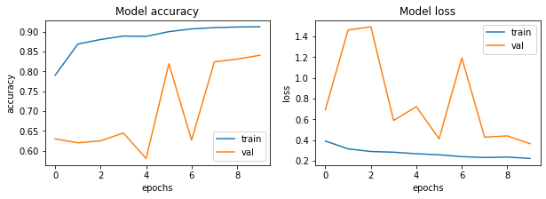

```python
fig, ax = plt.subplots(1, 2, figsize=(10, 3))
ax = ax.ravel()

for i, met in enumerate(['accuracy', 'loss']):
    ax[i].plot(history.history[met])
    ax[i].plot(history.history['val_' + met])
    ax[i].set_title('Model {}'.format(met))
    ax[i].set_xlabel('epochs')
    ax[i].set_ylabel(met)
    ax[i].legend(['train', 'val'])
```

```python
from sklearn.metrics import accuracy_score, confusion_matrix

preds = model.predict(test_data)

acc = accuracy_score(test_labels, np.round(preds))*100
cm = confusion_matrix(test_labels, np.round(preds))
tn, fp, fn, tp = cm.ravel()

print('CONFUSION MATRIX')
print(cm)

print('\nTEST METRICS')
precision = tp/(tp+fp)*100
recall = tp/(tp+fn)*100
print('Accuracy: {}%'.format(acc))
print('Precision: {}%'.format(precision))
print('Recall: {}%'.format(recall))
print('F1-score: {}'.format(2*precision*recall/(precision+recall)))

print('\nTRAIN METRIC')
print('Train acc: {}'.format(np.round((history.history['accuracy'][-1])*100, 2)))
```

```
CONFUSION MATRIX
[[178  56]
 [ 36 354]]

TEST METRICS
Accuracy: 85.25641025641025%
Precision: 86.34146341463415%
Recall: 90.76923076923077%
F1-score: 88.5

TRAIN METRIC
Train acc: 91.22
```

```python
model.summary()
```

```
Model: "model_2"
_________________________________________________________________
 Layer (type)                Output Shape              Param #
=================================================================
 input_1 (InputLayer)        [(None, 150, 150, 3)]     0

 conv2d (Conv2D)             (None, 150, 150, 16)      448

 conv2d_1 (Conv2D)           (None, 150, 150, 16)      2320

 max_pooling2d (MaxPooling2D  (None, 75, 75, 16)       0
 )

 separable_conv2d (Separable  (None, 75, 75, 32)       688
 Conv2D)

 separable_conv2d_1 (Separab  (None, 75, 75, 32)       1344
 leConv2D)

 batch_normalization (BatchN  (None, 75, 75, 32)       128
 ormalization)

 max_pooling2d_1 (MaxPooling  (None, 37, 37, 32)       0
 2D)

 separable_conv2d_2 (Separab  (None, 37, 37, 64)       2400
 leConv2D)

 separable_conv2d_3 (Separab  (None, 37, 37, 64)       4736
 leConv2D)

 batch_normalization_1 (Batc  (None, 37, 37, 64)       256
 hNormalization)

 max_pooling2d_2 (MaxPooling  (None, 18, 18, 64)       0
 2D)

 separable_conv2d_4 (Separab  (None, 18, 18, 128)      8896
 leConv2D)

```

[output cut: 31 more lines]

```
 dense_5 (Dense)             (None, 128)               65664

 dropout_5 (Dropout)         (None, 128)               0

 dense_6 (Dense)             (None, 64)                8256

 dropout_6 (Dropout)         (None, 64)                0

 dense_7 (Dense)             (None, 1)                 65

=================================================================
Total params: 5,529,505
Trainable params: 5,529,057
Non-trainable params: 448
_________________________________________________________________
```

```python
losses = pd.DataFrame(history.history)
losses.head(3)
```

|  | loss | accuracy | val_loss | val_accuracy | lr |
| --- | --- | --- | --- | --- | --- |
| 0 | 0.389579 | 0.790069 | 0.690900 | 0.629934 | 0.001 |
| 1 | 0.313612 | 0.868673 | 1.461448 | 0.620066 | 0.001 |
| 2 | 0.288289 | 0.880176 | 1.492410 | 0.625000 | 0.001 |

```python
pred_probability = model.predict_generator(test_data)
```

```python
pred_probability
```

[output not shown]

[output cut: 569 more lines]

[output not shown]

```python
loss,accuracy = model.evaluate(test_data)
```

```python
['NORMAL' if i<0.5 else 'PNEUMONIA' for i in pred_probability]
```

[output not shown]

[output cut: 569 more lines]

[output not shown]

# INFERENCE:

Accuracy: 85.25%

Precision: 86.34%

Recall: 90.76%

F1-score: 88.5